# Support Vector Machine

1. SVM pour des données séparables linéairement
2. SVM with Hinge loss
3. SVM with Ramp loss
4. SVM with Hard Margin Loss
5. Implémentation en python des différents classificateurs
6. Application à un jeu de données

Le SVM appartient à la catégorie des algorithmes de classification supervisé. En effet, c'est un classificateur linéaire dont l'objectif est de trouver la meilleur frontière c'est à dire celle séparant au mieux différentes catégories.

**De manière générale, un SVM cherchera à trouver un hyperplan qui sépare au mieux les catégories du problème.**

Les SVM peuvent séparer des points dans un espace de dimension quelconque. Par exemple, si on cherche à classer des individus par sexe et que l'on connait leur taille, leur poids et leur âge alors on travaillera en dimension 3.

L'objectif est donc de trouver un hyperplan vectoriel optimal d’équation :

[figure not shown]

## SVM pour des données séparables linéairement

[figure not shown]

Dans le cas ou le jeu de données est linéairement séparable, le problème d'optimisation est le suivant :

[figure not shown]

Celui-ci peut se reformuler de la facon suivante :

[figure not shown]

## SVM with Hinge loss

En général, Il se peut que des échantillons soient mal classifiés, et que l'hyperplan séparateur ne soit pas la meilleure solution au problème de classement.

En 1995, Corinna Cortes et Vladimir Vapnik proposent une technique dite de marge souple, qui tolère les mauvais classements. La technique cherche un hyperplan séparateur qui minimise le nombre d'erreurs grâce à l'introduction de variables ressort $\xi_{k}$ (slack variables en anglais), qui permettent de relacher les contraintes sur les vecteurs d'apprentissage.

[figure not shown]

Le problème d'optimisation devient alors :

[figure not shown]

L'idée du modèle est d'accepter la violation de certaines contrainte jusqu'à une certaine limite fixée par une constante C. Autrement dit, C est une constante qui permet de contrôler le compromis entre nombre d'erreurs de classement, et la largeur de la marge :

$\cdot$ Une valeur de C petite permet facilement d'ignorer certaines contraintes, on a alors une marge importante  
(C petit : forte variance et biais plus faible)  
$\cdot$ Une valeur de C importante empêche les contraintes d'être ignorées et entraine donc une marge étroite (C grand : faible variance et biais plus fort )

Ce paramètre peut être déterminé par validation croisée en utilisant les exemples d'apprentissages.

## SVM with Ramp loss

[figure not shown]

## SVM with Hard Margin Loss

[figure not shown]

## Implémentation en python des différents classificateurs

#### Importation des librairies

```python
import pandas as pd
import numpy as np
import matplotlib.pyplot  as plt
import docplex.mp.model as cpx
from sklearn import datasets, linear_model
from sklearn.model_selection import train_test_split
import seaborn as sns
from scipy import stats
import cplex
```

#### SVM with Hinge loss

```python
def solveurHL(C, xtrain, ytrain):
    prob = cpx.Model(name = "Hinge loss")

    # Define the decision variables
    w =  {i : prob.continuous_var(lb= -10000, name='w{0}'.format(i)) for i in range(xtrain.shape[1])}
    epsilon = {i : prob.continuous_var(lb=0, name="epsilon{0}".format(i)) for i in range(xtrain.shape[0])}
    b = prob.continuous_var(name="b")

    # Define the Constraints
    for i in range(xtrain.shape[0]) :
        if (ytrain[i]==1):
            prob.add_constraint(prob.sum(xtrain[i][j]*w[j] for j in range(xtrain.shape[1])) + b + epsilon[i]>= 1)
        else:
            prob.add_constraint(prob.sum(xtrain[i][j]*w[j] for j in range(xtrain.shape[1])) + b - epsilon[i] <= -1)

    # Objective function
    prob.minimize(0.5 * prob.sumsq(w[i] for i in range(xtrain.shape[1])) + C * (prob.sum(epsilon[i] for i in range(xtrain.shape[0]))) )

    prob.solve()

    # Organisation of the results in dataframe
    df_w = pd.DataFrame.from_dict(w, orient="index", columns = ["var_w"])
    df_w["value_w"] = df_w["var_w"].apply(lambda item: item.solution_value)

    b = b.solution_value

    return df_w, b
```

#### SVM with Ramp loss

```python
def solveurRL(C, xtrain, ytrain, M):
    prob = cpx.Model(name = "Ramp loss")

    # Define the decision variables
    w =  {i : prob.continuous_var(name='w{0}'.format(i)) for i in range(xtrain.shape[1])}
    epsilon = {i : prob.continuous_var(lb=0, ub = 2, name="epsilon{0}".format(i)) for i in range(xtrain.shape[0])}
    b = prob.continuous_var(name="b")
    z = {i : prob.binary_var(name='z{0}'.format(i)) for i in range(xtrain.shape[0])}

    # Define the Constraints
    for i in range(xtrain.shape[0]) :
        if (ytrain[i]==1):
            prob.add_constraint(prob.sum(xtrain[i][j]*w[j] for j in range(xtrain.shape[1])) + b + epsilon[i] + M * z[i] >= 1)
        else:
            prob.add_constraint(prob.sum(xtrain[i][j]*w[j] for j in range(xtrain.shape[1])) + b - epsilon[i] - M * z[i] <= -1)

    # Objective function
    prob.minimize(0.5 * prob.sumsq(w[i] for i in range(xtrain.shape[1])) + C * ( prob.sum(epsilon[i] for i in range(xtrain.shape[0])) + 2 * prob.sum(z[i] for i in range(xtrain.shape[0]))))

    prob.solve()

    # Organisation of the results in dataframe
    df_w = pd.DataFrame.from_dict(w, orient="index", columns = ["var_w"])
    df_w["value_w"] = df_w["var_w"].apply(lambda item: item.solution_value)

    b = b.solution_value

    return df_w, b
```

#### SVM with Hard Margin Loss

```python
def solveurHML(C, xtrain, ytrain, M):
    prob = cpx.Model(name = "Hard Margin Loss")

    # Define the decision variables
    w =  {i : prob.continuous_var(name='w{0}'.format(i)) for i in range(xtrain.shape[1])}
    b = prob.continuous_var(name="b")
    z = {i : prob.binary_var(name='z{0}'.format(i)) for i in range(xtrain.shape[0])}

    # Define the Constraints
    for i in range(xtrain.shape[0]) :
        if (ytrain[i]==1):
            prob.add_constraint(prob.sum(xtrain[i][j]*w[j] for j in range(xtrain.shape[1])) + b + M * z[i] >= 1)
        else:
            prob.add_constraint(prob.sum(xtrain[i][j]*w[j] for j in range(xtrain.shape[1])) + b - M * z[i] <= -1)

    # Objective function
    prob.minimize(0.5 * prob.sumsq(w[i] for i in range(xtrain.shape[1])) + C * (prob.sum(z[i] for i in range(xtrain.shape[0]))))

    prob.solve()

    # Organisation of the results in dataframe
    df_w = pd.DataFrame.from_dict(w, orient="index", columns = ["var_w"])
    df_w["value_w"] = df_w["var_w"].apply(lambda item: item.solution_value)
    b = b.solution_value

    return df_w, b
```

## Application à un jeu de données

#### Importation et analyse des données

```python
df = pd.read_csv('H:/Desktop/diabetes.csv', sep=',', engine='python')

df2 = df[['timespreg', 'gluctol', 'diaspb', 'triceps', 'insulin', 'massindex', 'pedigree', 'age']]
df2.describe()
```

|  | timespreg | gluctol | diaspb | triceps | insulin | massindex | pedigree | age |
| --- | --- | --- | --- | --- | --- | --- | --- | --- |
| count | 768.000000 | 768.000000 | 768.000000 | 768.000000 | 768.000000 | 768.000000 | 768.000000 | 768.000000 |
| mean | 3.845052 | 120.894531 | 69.105469 | 20.536458 | 79.799479 | 31.992578 | 0.471876 | 33.240885 |
| std | 3.369578 | 31.972618 | 19.355807 | 15.952218 | 115.244002 | 7.884160 | 0.331329 | 11.760232 |
| min | 0.000000 | 0.000000 | 0.000000 | 0.000000 | 0.000000 | 0.000000 | 0.078000 | 21.000000 |
| 25% | 1.000000 | 99.000000 | 62.000000 | 0.000000 | 0.000000 | 27.300000 | 0.243750 | 24.000000 |
| 50% | 3.000000 | 117.000000 | 72.000000 | 23.000000 | 30.500000 | 32.000000 | 0.372500 | 29.000000 |
| 75% | 6.000000 | 140.250000 | 80.000000 | 32.000000 | 127.250000 | 36.600000 | 0.626250 | 41.000000 |
| max | 17.000000 | 199.000000 | 122.000000 | 99.000000 | 846.000000 | 67.100000 | 2.420000 | 81.000000 |

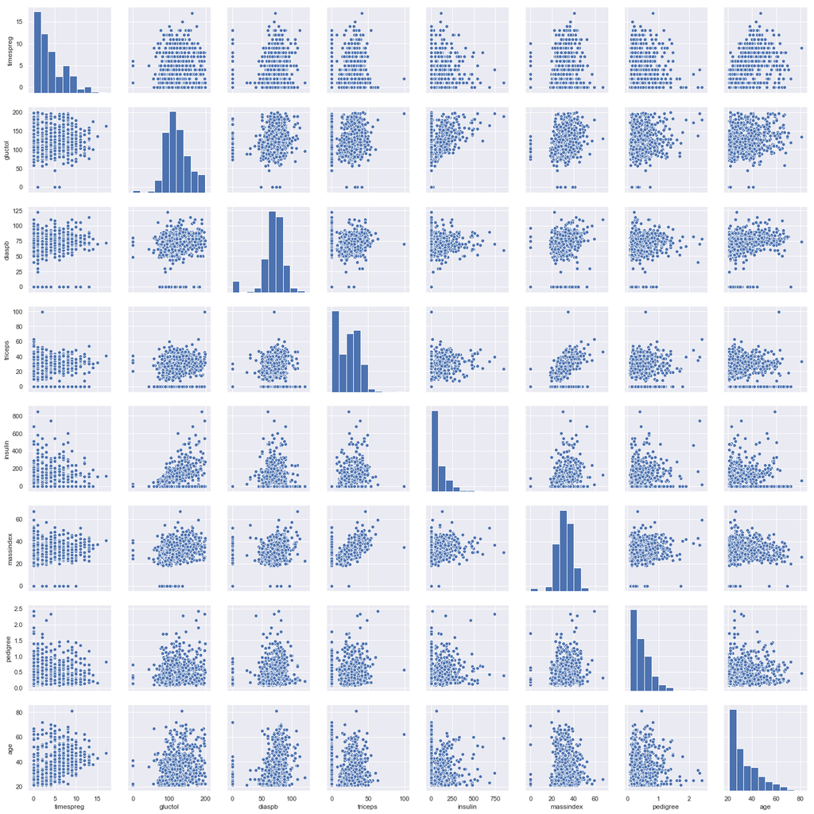

```python
sns.set(style="darkgrid")
sns.pairplot(df2)
```

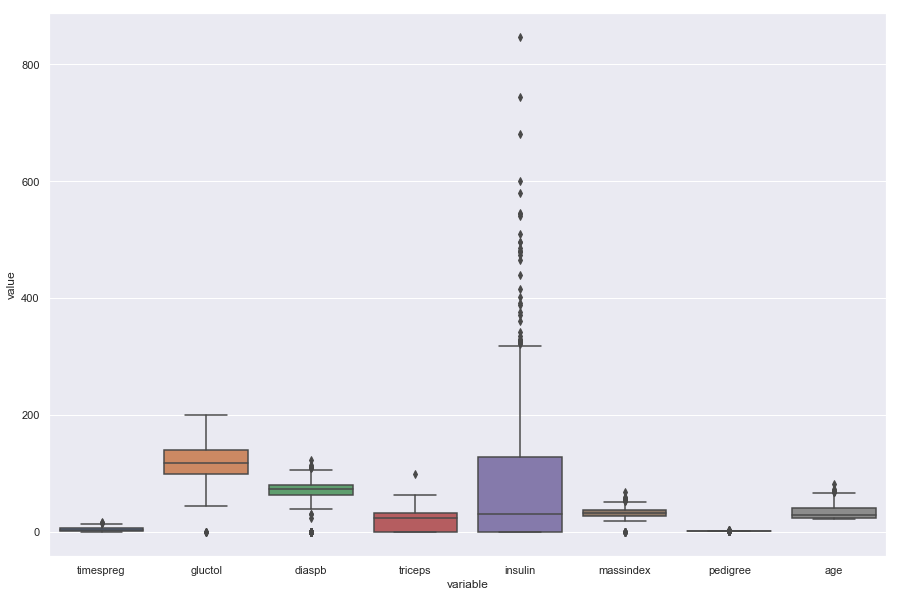

```python
fig, ax = plt.subplots(figsize=(15, 10))
sns.boxplot(x="variable", y="value", data=pd.melt(df2))
```

#### Pré-traitement du jeu de données

```python
# Suppression des outliers en utilisant le Z-score
df = df[(np.abs(stats.zscore(df)) < 3).all(axis=1)]

# Séparation des données en training et testing set
xtrain, xtest, ytrain, ytest = train_test_split(df.drop("target",axis=1), df["target"], test_size=0.3)

xtrain=np.array(xtrain)
ytrain=np.array(ytrain)
```

Deplus, comme le jeu de données est composé de n observations en dimension d tel que :

$(x_{i}, y_{i}) \in R^d \times \left\{ -1,1 \right\} \hspace{3cm} i= 1,...,n$

Nous devons transformer le dataset d'entrainement :

```python
ytrain[ytrain==2]=-1
ytest[ytest==2]=-1
```

#### Mesure de la qualité du modèle

```python
def qualitySolver(xtrain, ytrain, xtest, ytest, C, M, solver):
    res_prediction = []

    if solver == 'HL':
        df_w, b = solveurHL(C, xtrain, ytrain)
        for j in range(0,(xtest.shape[0])):
            res_prediction.append(np.sign(np.inner(df_w["value_w"], xtest.iloc[j,:]) + b))

    if solver == 'RL':
        df_w, b = solveurRL(C, xtrain, ytrain, M)
        for j in range(0,(xtest.shape[0])):
            res_prediction.append(np.sign(np.inner(df_w["value_w"], xtest.iloc[j,:]) + b))

    if solver == 'HML':
        df_w, b = solveurHML(C, xtrain, ytrain, M)
        for j in range(0,(xtest.shape[0])):
            res_prediction.append(np.sign(np.inner(df_w["value_w"], xtest.iloc[j,:]) + b))

    target = np.array(ytest)
    TP = np.zeros(shape=target.shape[0])
    TN = np.zeros(shape=target.shape[0])
    FP = np.zeros(shape=target.shape[0])
    FN = np.zeros(shape=target.shape[0])

    i=0
    for row in target:
        if (row == 1) and (res_prediction[i]) == 1:
            TP[i] = 1
        elif (row == 1) and (res_prediction[i]) == -1:
            FN[i] = 1
        elif (row == -1) and (res_prediction[i] == 1):
            FP[i] = 1
        elif (row == -1) and (res_prediction[i] == -1):
            TN[i] = 1
        i = i+ 1

    Confusion_matrix = [[np.sum(TP), np.sum(FN)], [np.sum(FP), np.sum(TN)]]

    if ((Confusion_matrix[0][0] + Confusion_matrix[0][1]) != 0):
        Sensitivity = Confusion_matrix[0][0] / (Confusion_matrix[0][0] + Confusion_matrix[0][1])
        Precision = Confusion_matrix[0][0] / (Confusion_matrix[0][0] + Confusion_matrix[1][0])
        print("Sensitivity = ", Sensitivity)
        print("Precision = ", Precision)

    if ((Confusion_matrix[0][0] + Confusion_matrix[1][1] + Confusion_matrix[0][1] + Confusion_matrix[1][0]) != 0):
        Accuracy = (Confusion_matrix[0][0] + Confusion_matrix[1][1]) / (Confusion_matrix[0][0] + Confusion_matrix[1][1] + Confusion_matrix[0][1] + Confusion_matrix[1][0])
        print("Classifier Accuracy = ", Accuracy )
```

#### Test du modèle Hinge Loss avec C = 10

```python
qualitySolver(xtrain, ytrain, xtest, ytest, 10, None, 'HL')
```

```
Sensitivity =  0.8611111111111112
Precision =  0.8157894736842105
Classifier Accuracy =  0.7681159420289855
```

#### References

https://fr.wikipedia.org/wiki/Machine_%C3%A0_vecteurs_de_support  
https://zestedesavoir.com/tutoriels/1760/un-peu-de-machine-learning-avec-les-svm/  
http://www.robots.ox.ac.uk/~az/lectures/ml/lect2.pdf  
https://pdfs.semanticscholar.org/3300/3fd597ccaa96f6a67122adcf3f05f2af3bee.pdf  
http://pageperso.univ-lr.fr/arnaud.revel/MesPolys/SVM.pdf